# A Short Map Tutorial

Introduction to QGIS

Matthew Jura

2016-07-19

# Prerequisites

## Download software

For simpplicity of the installation and functionality QGIS seems to be a ligitimate choice. The software is available on major OS platforms (Windows, macOS, Linux). You can find a software [here](http://www.qgis.org/en/site/forusers/download.html) and download version that is compatibile with your operating system. The file is quite big, and installation process may take a while. After downloading an installer, just follow instructions. There is no need to download additional data sources during the installation process. Although, you can do it later.

## The Goal

1. Introduction to GIS data types and visualizations.
2. Create simple thematic maps and integrate them with external data sources.
3. Create and export a map for further publication or post-processing.

This short introduction is intended to only familiarize you with basic functions of GIS and give an overview of spatial data.

# GIS Data

## Spatial Objects (data types)

### Vector data

1. Polygons - to represent areas or surfaces: boarders of countries, states, coutnies, or islands.
2. Lines - mostly for roads or rivers. They are different from lines to create a polygon.
3. Points - a particular point in space (a pin on a map); specific site: hospital, firestation, household, etc.

### Raster data

A grid of georeferenced cells (usually squared pixels) with assigned value, similarly to regular bitmap image.

Vector object can be scaled in any direction without loosing quality of an image, which is not a case in raster data. It may be impossible to change a projection of a raster images, since raster cells are coupled with particular reference system. When projection changes the shape of cells may change too.

## File formats

Spatial file formats correspond closely to the spatial types. We focus on vector files, since they are the most flexible and easy to make visualizations.

1. Shapefile format - SHP - contains only spatial information; feature geometry, this file has to be accompanied by at least two other files to make a data complete:
- .shx - spatial index file
- .dbf – dBase file format which contains all attributes data – all other non-geographical information about each spatial element in the *.shp file; e.g. name, number of population, time, etc.

  One of many different database formats keeping all the information in one file. The reason to keep attributable information in database format is to facilitate database queries in GIS software.
- other files contain additional information specific to indexing and other metadata; they are not required but may be created by additinal software.
2. [KML](https://en.wikipedia.org/wiki/Keyhole_Markup_Language) format - Keyhole Markup Language - XML based file format to encapsulate both geographically referenced and attributable data.
3. GeoTIFF - raster image TIFF format with additional layer of geo-referencing information. The data can be very precise, however it may contain only a single feature for one pixel element.
4. Many more - you can find more information about different spatial data file formats [here](https://en.wikipedia.org/wiki/GIS_file_formats).

## Types of thematic maps

[Choropleth maps](https://en.wikipedia.org/wiki/Choropleth_map) – made of polygons with set of features based on attributable information. E.g. hue of a color is to depict change of some quantitative information.

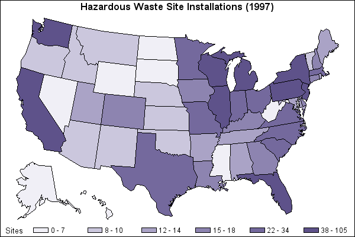

Choropleth map

Cartograms (proportional symbol) - spatial elements are scaled based on some quantity. Commonly used to display more than one variable; but they can be easily be very clunky.

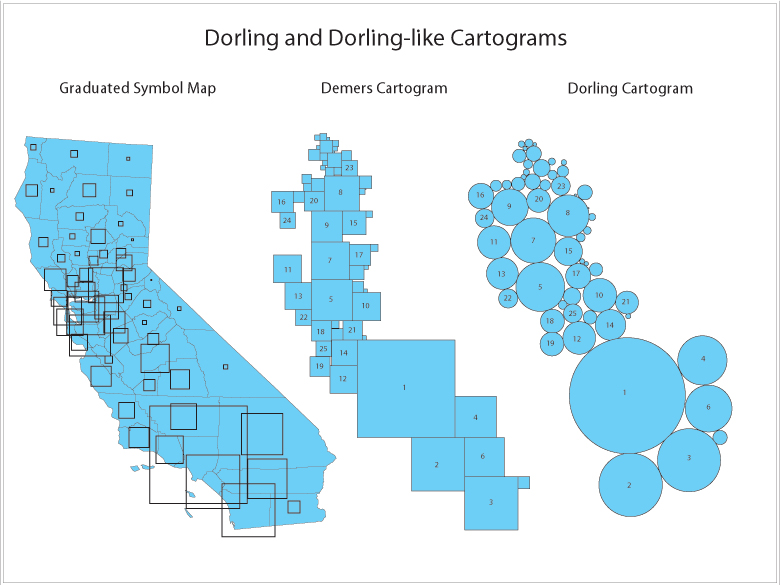

Cartogram

Isopleth (isarithmic) – show smooth changes of quantitative phenomenon (precipitation, air pressure, elevation).

One option are density maps - based on point information; they show how the density of points (e.g. crimes) is distributed over space.

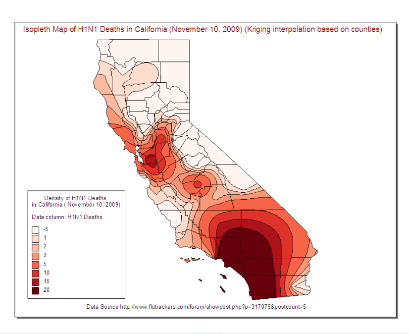

Isopleth map

Dot maps - plain dots plotted over a geographical region to depict spatial distribution of points. To plot many points overlapping on small areas it is better to convert them to densities, or aggregate them into arbitrary polygons. Common practice is to use hexagonal polygons.

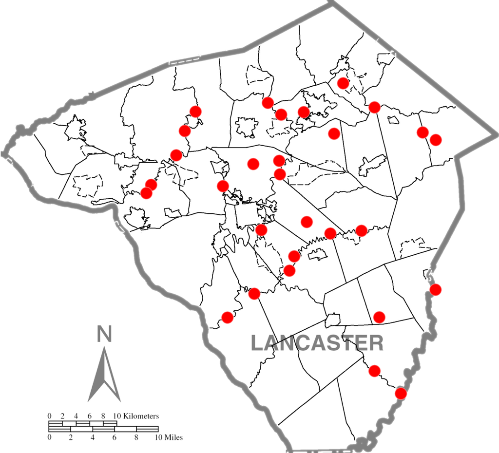

Dot map

[Dasymetric maps](https://en.wikipedia.org/wiki/Dasymetric_map) – a mix of *isopleth* and *choropleth* map. Usually incorporates additional statistical procedures like interpolation; although may help to depict a phenomenon in more realistic way.

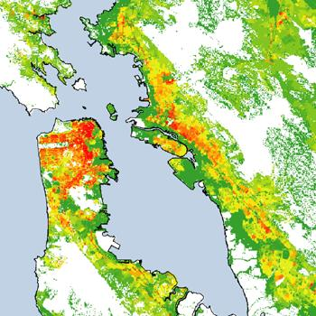

Dosymetric maps

All the maps listed can be overlay on a reference (base) map to help find the right location or familiarize reader with a region. Good examples are Google Maps or OpenStreet Map.

## Projections

To draw 3-dimensional space on a flat surface of a map we need to make a projection. Different projections are available to preserve specific data: distance, area, shape, etc. The original spatial data describing locations on Earth (a sphere) uses latitude and longitude expressed in degrees (minutes, seconds). In order to change the units, for example to calculate a distance (in miles or kilometers) we need to project spherical dimensions to flat 2-dimensional surface.

We can use projections that still retain angular units but the lines of latitude and longitude for represented as straight lines - the most common is [Mercator projection](https://en.wikipedia.org/wiki/Mercator_projection); which is compliant with WGS84 coordinate system. Mercator projection is suitable for visualizing large areas. In case of small regions or countries there are many different projections available. It is common that projection names are after country names or some geographical names.

This may be very important when you try overlay maps from different sources with completely different projections. Without unifying projections visual results may be completely wrong. Many of the geocoding services provide latitude and longitude in degrees with decimal precision. If you obtain the location in degrees, minutes and seconds you need to make the unit conversion first. The reference point for all locations (at most of the cases) is the central Meridian located in Greenwich, London.

# Making a Thematic Map

## Adding external data file to a map

1. With created new project file add a vector layer from the toolbox on the left-hand side.
2. Open map attributes dialog-box in order to inspect attribute data and identify a variable which will help to match records with additional information.
3. *Link* external non-georeferenced data file (text or CSV).
4. Create a join between the spatial layer and the external data file.
   1. Right-click on the target layer, choose *Properties*.
   2. In the new dialog-box select tab *Joins*.
   3. Click ‘+’ sign to add a new join.
   4. Select which layers are joined and which variable is used to match two datasets (match between the records in the *.dbf file and new source in external dataset).
   5. Accept changes, right click again on the target layer and choose ‘Open Attribute table’.
   6. Inspect if the correct variables were added.
5. Assign colors and labels to the geographical locations (see below).

The external data file is only linked to the spatial object. Any changes made in the external dataset will be reflected once QGIS reloads the project (e.g. when you restart it).

## Creating new regions based on geometries

1. On the open layer inspect the attributes table to identify a feature based on which new region will be created.
   1. To create a map of regions based on counties *.shp file, we have to add a feature to identify which county is assigned to a specific region.
   2. The new feature can exist in the external data file (e.g. CSV) which has to be merged with spatial object first (as described above).
   3. Merging spatial objects into larger spatial objects results in creating a new *.shp file.
2. From menu Vector -> Geoprocessing Tools -> Dissolve
   1. Select the vector layer to be dissolved.
   2. Check the field (feature) on which the areas will be merged.
   3. Define the name of the output *shapefile*. In this case we create a new spatial file.
   4. Select ‘Add result to canvas’, so the new shapefile is added to the project.
3. Additional attributes can be added to the new shapefile.

## Coloring regions and adding labels

1. All coloring and labeling options are available in the ‘Properties’ dialog box.
2. Just right click on a desired layer and select ‘Properties’. Or double click on the layer.
3. There are two tabs for Styles and Labels.
   1. Styles give you options for coloring spatial objects based on different color schemes.
   2. Labels give you options to add labels and style them. Labels are created from a variable that should be in Attributes table.

### Adding labels positioned manually

By default text labels are added relatively to the spatial object: point, line, polygon. However, sometimes you may need to manually adjust the position of a text label, because the default position makes another element underneath invisible.

1. Open layer *Properties*
2. In the *Fields* tab add two new variables: ‘lab_x’ and ‘lab_y’. The data type for both should be numeric (float).
3. Open *Labels* tab (still in the same *Properties* dialog.
4. Select option *Show labels in this layer*. Select which variable is a source of the label for each spatial element.
5. Select *Placement* properties on the list which is in the lower part of the dialog-box:
   1. Select placement type to *Free*.
   2. In *Data defined* section select the attributes for label *Coordinates*.
   3. ‘lab_x’ for X coordinates and ‘lab_y’ for Y coordinates.
   4. The attributes (fields) we created in the step 2 will keep the coordinates for each text label, so later you can change them manually.
6. Accept the changes and close the *Properties* dialog-box.
7. To manually change a position of the label activate *edit mode* for the layer.
8. Choose ‘Change label’ tool from the toolbar and adjust label position manually.

You can always add more attributes for other label features (visibility, angle, color). The process is always the same: you need to create new attribute then link it to label feature in the *Properties* dialog box.

## Creating an output map

1. Add new map composer from the toolbar.
2. It opens a new map creator, which later you can reuse.
3. Add a map to the map canvas. All the tools are located in the left-hand side toolbar.
4. You can add maps, labels, legends using tools.
5. Export a map to a desired file format (PNG, PDF, SVG).

Since QGIS is not a perfect tool some glitches are present. Particularly with making an output map the interface is not really responsive in fitting a map in desired box on the canvas. In some situations you may have to put the exact scale of the map. There is a number of options in settings panel located on the right side of the map creator dialog box.

If you want to just save the map as image, without the legend, you can choose *Save as Image* option from the *Project* menu to save the map the way it is currently visible in the main window.

## Keep in mind

1. To apply any changes to spatial objects on any layer you have to activate *Edit mode* first. Disabling edit mode results in saving changes to a *.shp file.
2. QGIS project does not encapsulate any source files used as layers. The file paths to the source files (*.shp and related files) are relative to the location of a project. When you move your project file elsewhere you need to move all the associated files. It is better to keep all the files in one folder.
3. The original spatial objects (e.g. polygons) always sit in the *.shp file. When you create new object you have to save it in a new* .shp file.
4. If you have few layers referenced to the same *.shp file, any change in* .shp will be reflected in all the layers.

# Cartographic tips

## Making data spatial (geocoding)

In case you need convert your data (e.g. address) to a legitimate geographic information: latitude and longitude you need to geocode this information. With single addresses it is very simple, you can use for example Google Maps. In case you have 100 addresses it may be a little time consuming. To make batch conversion you can utilize Google Fusion Tables or OpenRefine (formerly known as GoogleRefine). Both software offer a batch geocoding using Google maps servers free of charge up to 5k records a day.

# Additional resources

[Cartographic Boundary Shapefiles](https://www.census.gov/geo/maps-data/data/tiger-cart-boundary.html) - US Census Bureau

[Many data sources](http://www.colorado.edu/geography/gcraft/notes/sources/sources_f.html) are available at the University of Colorado website.

[QGIS Book (Ed.3)](https://play.google.com/store/books/details/Anita_Graser_Learning_QGIS?id=rUXiCwAAQBAJ) - QGIS book written by the QGIS creator Anita Graser

[Coursera Specialization in GIS](https://www.coursera.org/specializations/gis) - Never took it, but you can always audit the course.